[Run on Google Colab](https://colab.research.google.com/github/Hari31416/Portfolio/blob/main/ML/Housing_Price/Modeling.ipynb?hl=en)

[View on Github](https://github.com/Hari31416/Portfolio/blob/main/Housing_Price/ML/Modeling.ipynb)

# Imports

```python
import pandas as pd
import numpy as np
import matplotlib.pyplot as plt

from sklearn.linear_model import LinearRegression, ElasticNet, Lasso, Ridge
from sklearn.model_selection import train_test_split, cross_val_score, GridSearchCV
from sklearn.preprocessing import PolynomialFeatures
from sklearn.svm import SVR
from sklearn.metrics import mean_squared_error, r2_score
```

# Preprocessing

## Loading The Data

Let's start by loading the data.

```python
X = pd.read_csv('data/train_final.csv')
test = pd.read_csv('data/test_final.csv')
y = pd.read_csv('data/y.csv')
```

Next step is to create the train and test sets as the data is already normalized.

## Making The Train and Test Sets

```python
len(X)
```

```
1460
```

We see that we have just 1460 training examles. So, we should not be using a lot of examples for the test set. ABout 150 examples have to suffice.

```python
X_train, X_test, y_train, y_test = train_test_split(X, y, test_size=0.10, random_state=42)
len(X_train), len(X_test)
```

```
(1314, 146)
```

# Modeling

## Creating Some Functions

```python
def evaluate_model(y_true, y_pred = None, model=None, X_test=None):
    """
    Evaluates a model by computing the mean squared error and the r2 score.

    Parameters
    ----------
    y_true : pandas.Series
        The true values of the target variable.
    y_pred : pandas.Series
        The predicted values of the target variable.
        if None, the model is evaluated on the test set. `model` and `X_test` must be provided.
    model : sklearn.linear_model.LinearRegression
        The model to evaluate. Optional if `y_pred` is provided.
    X_test : pandas.DataFrame
        The test set. Optional if `y_pred` is provided.

    Returns
    -------
    rmse : float
        The root mean squared error.
    r2 : float
        The r2 score.
    ratio : float
        The ratio of the mean squared error to the mean value of the target variable.
    """
    rmse = mean_squared_error(y_true, y_pred)**0.5
    r_score = r2_score(y_true, y_pred)
    ratio = (rmse / y_true.mean()).values[0]
    result = {'rmse': rmse, 'r2': r_score, 'ratio': ratio}
    print('rmse:', rmse)
    print('R2:', r_score)
    print('Ratio:', ratio)
    return result
```

## The Base Model

Let's create a base model. We'll use a linear regression model with default parameters for this

```python
lr_base = LinearRegression()
lr_base.fit(X_train, y_train)
```

```
LinearRegression()
```

```python
y_pred = lr_base.predict(X_test)
base_model_result = evaluate_model(y_test, y_pred)
```

```
rmse: 47435.83771241819
R2: 0.753721417512423
Ratio: 0.25939742165697893
```

```python
y_pred = lr_base.predict(X_train)
evaluate_model(y_train, y_pred)
```

```
rmse: 38107.493570595456
R2: 0.7576423209884251
Ratio: 0.21088265173229595
```

```
{'rmse': 38107.493570595456,
 'r2': 0.7576423209884251,
 'ratio': 0.21088265173229595}
```

Now, as our base model is here, we can start experimenting.

## Polynomial Model

Let's fit a polynomial model of order 2 on the training data.

```python
pf = PolynomialFeatures(degree=2)
X_train_pf = pf.fit_transform(X_train)
X_test_pf = pf.fit_transform(X_test)
```

```python
lr_pf = LinearRegression()
lr_pf.fit(X_train_pf, y_train)
```

```
LinearRegression()
```

```python
y_pred = lr_pf.predict(X_test_pf)
poly_reg_result =  evaluate_model(y_test, y_pred)
```

```
rmse: 68232.86347065943
R2: 0.4904337089356018
Ratio: 0.37312356458982066
```

```python
y_pred = lr_pf.predict(X_test_pf)
y_pred = np.abs(y_pred)
poly_reg_result =  evaluate_model(y_test, y_pred)
```

```
rmse: 56795.40174109139
R2: 0.646947047454522
Ratio: 0.31057912085221945
```

It is performing worse than the base model. What's more, sometimes, the model in return negative values for the predictions.

```python
evaluate_model(y_train, lr_pf.predict(X_train_pf))
```

```
rmse: 161.90692028798085
R2: 0.9999956251130148
Ratio: 0.0008959749772282216
```

```
{'rmse': 161.90692028798085,
 'r2': 0.9999956251130148,
 'ratio': 0.0008959749772282216}
```

So this is why the model is perfoming this terribly on test set. The model is overfitting quite severely. Let's try some regularization techniques and grid search to find the best parameters.

#### First Iteration

```python
param_grid = {"alpha": [0.01, 0.1, 1, 10, 100], "l1_ratio": [0.1,0.3, 0.5, 0.7, 0.9]}
base_model = ElasticNet(random_state=42, max_iter=10000)
grid_model = GridSearchCV(base_model, param_grid, cv=3, scoring='neg_mean_squared_error', verbose =1)
grid_model.fit(X_train_pf, y_train)
```

```
Fitting 3 folds for each of 25 candidates, totalling 75 fits
```

```
[Parallel(n_jobs=1)]: Using backend SequentialBackend with 1 concurrent workers.
```

[output not shown]

[output cut: 60 more lines]

[output not shown]

```python
grid_model.best_params_
```

```
{'alpha': 1, 'l1_ratio': 0.5}
```

#### Second Iteration

```python
param_grid = {"alpha": [0.8, 1, 2, 5], "l1_ratio": [0.4, 0.5, 0.6,]}
base_model = ElasticNet(random_state=42, max_iter=10000)
grid_model = GridSearchCV(base_model, param_grid, cv=3, scoring='neg_mean_squared_error')
grid_model.fit(X_train, y_train)
```

```
GridSearchCV(cv=3, estimator=ElasticNet(max_iter=10000, random_state=42),
             param_grid={'alpha': [0.8, 1, 2, 5], 'l1_ratio': [0.4, 0.5, 0.6]},
             scoring='neg_mean_squared_error')
```

```python
grid_model.best_params_
```

```
{'alpha': 0.8, 'l1_ratio': 0.5}
```

#### Third Iteration

```python
param_grid = {"alpha": [0.6, 0.7, 0.8, 0.9], "l1_ratio": [0.45, 0.5, 0.55,]}
base_model = ElasticNet(random_state=42, max_iter=10000)
grid_model = GridSearchCV(base_model, param_grid, cv=3, scoring='neg_mean_squared_error')
grid_model.fit(X_train, y_train)
```

```
GridSearchCV(cv=3, estimator=ElasticNet(max_iter=10000, random_state=42),
             param_grid={'alpha': [0.6, 0.7, 0.8, 0.9],
                         'l1_ratio': [0.45, 0.5, 0.55]},
             scoring='neg_mean_squared_error')
```

```python
grid_model.best_params_
```

```
{'alpha': 0.8, 'l1_ratio': 0.45}
```

This is the final parameters that we have selected.

```python
el_net_best_model = grid_model.best_estimator_
el_net_best_model.fit(X_train, y_train)
```

```
ElasticNet(alpha=0.8, l1_ratio=0.45, max_iter=10000, random_state=42)
```

```python
y_pred = el_net_best_model.predict(X_test_pf)
evaluate_model(y_test, y_pred)
```

[output not shown]

```python
evaluate_model(y_train, el_net.predict(X_train_pf))
```

[output not shown]

```
{'rmse': 9501.954771838984,
 'r2': 0.9849317806911022,
 'ratio': 0.05258276604347236}
```

### Neural Network

```python
import tensorflow.keras.layers as layers
from tensorflow.keras.models import Sequential
```

```python
model = Sequential()
model.add(layers.Dense(64, activation='relu', input_shape=(X_train.shape[1],)))
model.add(layers.Dense(128, activation='relu'))
model.add(layers.Dropout(0.3))
model.add(layers.Dense(128, activation='relu'))
model.add(layers.Dropout(0.3))
model.add(layers.Dense(256, activation='relu'))
model.add(layers.Dense(1))
model.summary()
```

```
Model: "sequential_2"
_________________________________________________________________
Layer (type)                 Output Shape              Param #
=================================================================
dense_7 (Dense)              (None, 64)                6144
_________________________________________________________________
dense_8 (Dense)              (None, 128)               8320
_________________________________________________________________
dropout_1 (Dropout)          (None, 128)               0
_________________________________________________________________
dense_9 (Dense)              (None, 128)               16512
_________________________________________________________________
dropout_2 (Dropout)          (None, 128)               0
_________________________________________________________________
dense_10 (Dense)             (None, 256)               33024
_________________________________________________________________
dense_11 (Dense)             (None, 1)                 257
=================================================================
Total params: 64,257
Trainable params: 64,257
Non-trainable params: 0
_________________________________________________________________
```

```python
model.compile(optimizer='adam', loss='mse', metrics=['mae'])
history = model.fit(X, y, epochs=100, validation_split=0.2)
```

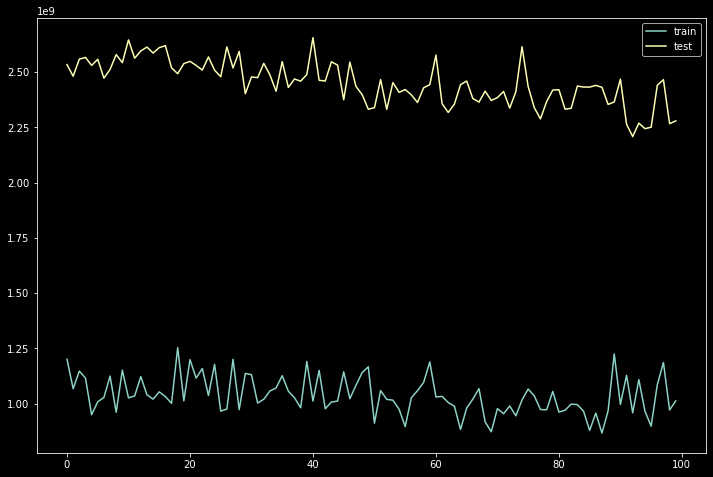

```python
plt.figure(figsize=(12,8))
plt.plot(history.history['loss'], label='train')
plt.plot(history.history['val_loss'], label='test')
plt.legend()
```

```python
pred = model.predict(test)
label = pd.read_csv('data/test_Id.csv')
assert len(pred) == len(label)
sub = pd.DataFrame(label["Id"], columns=["Id"])
sub["SalePrice"] = pred
sub.to_csv('data\submissions\submission_2.csv', index=False)
```

```python
!kaggle competitions submit -c house-prices-advanced-regression-techniques -f data\submissions\submission_2.csv -m "Second submission"
```

```
Successfully submitted to House Prices - Advanced Regression Techniques
```